# Analysis

link

We describe here our detailed data analysis. Most of our data for analysis is accredited to UNICEF database.

```
## [1] "/Users/francescobenatti/Library/Mobile Documents/com~apple~CloudDocs/BU/MA615 Data Science with R/ma4615-fa22-final-project-team-whatever/content"
```

```
## [1] "income_mortality" "nd_inc_mort_avg"  "nd_regions"
```

## Our Motivation for Analysis

Our data is mainly driven by investigating the state of the world’s children under the age of 5. Through our analysis, we will have a better idea of how influential our chosen variables are to the survival and health of children around the world.

Some variables we are most interested in include:

```
* Nutrition
* Low birth weight
* Minimum diet diversity(6-23months)
* Minimum meal frequency(6-23months)
* Zero vegetable or fruit consumption (6-23months)
+ Mortality Rate
        * Includes years 1950 - 2020
+ Income per capita
```

With these variables, we hope to learn more about the connection between economics, nutrition, and child mortality across regions. We can also try to get some idea as to what triggers a higher child mortality rate in particular nations with respect to the variables above. Then, we could compare the differences with countries with a lower rate. As a result, it might be possible to pinpoint improvements that could be made to the children’s living circumstances as well as the areas where making changes would have the greatest potential to save young lives.

## Initial Questions

1. What are the differences in low birthweight between each world region?
2. What is the relationship over time between mortality rates for children under the age of 5?
3. Does income have a significant contribution to the characteristics of a country with lower mortality rates?
4. What are some relationships between nutrition variables, such as exclusive breast feeding rate and the average income per capita per region?
5. As the income increases, does diet diversity also increase for the children’s nutrition?

## Flaws and Limitations of Analysis

One unfortunate limitation is that the Nutrition data set does not have an extensive time series like the Mortality rates data set. So, if our combined data set for nutrition/income/mortality, we are unable to have a variable for years. We combined data from more than 150 countries across the three tables that left us with some usable information.

Not having an appropriate amount of values in the nutrition data for some variables also limits us to have an equitable representation of these variables.

We are also limited in saying that certain factors are what “cause” lower nutritional values in countries, because since we are looking at country-wide data, there will inevitably be many factors that are potential contributers. But for our project, we hope to be able to create a profile using the variables we chose and be able to predict the nutritional or mortality status of a country based on these chosen factors.

## Figure one: Low Birthweight in each Region

Here, we wanted to give a visual to represent the percentage variability in low birthweight among these regions. Based on the bar chart, South Asia has a visible larger percentage of children that fall in this category. Moving forward, we will keep an eye on South Asia and the relationships that may have impacted this one.

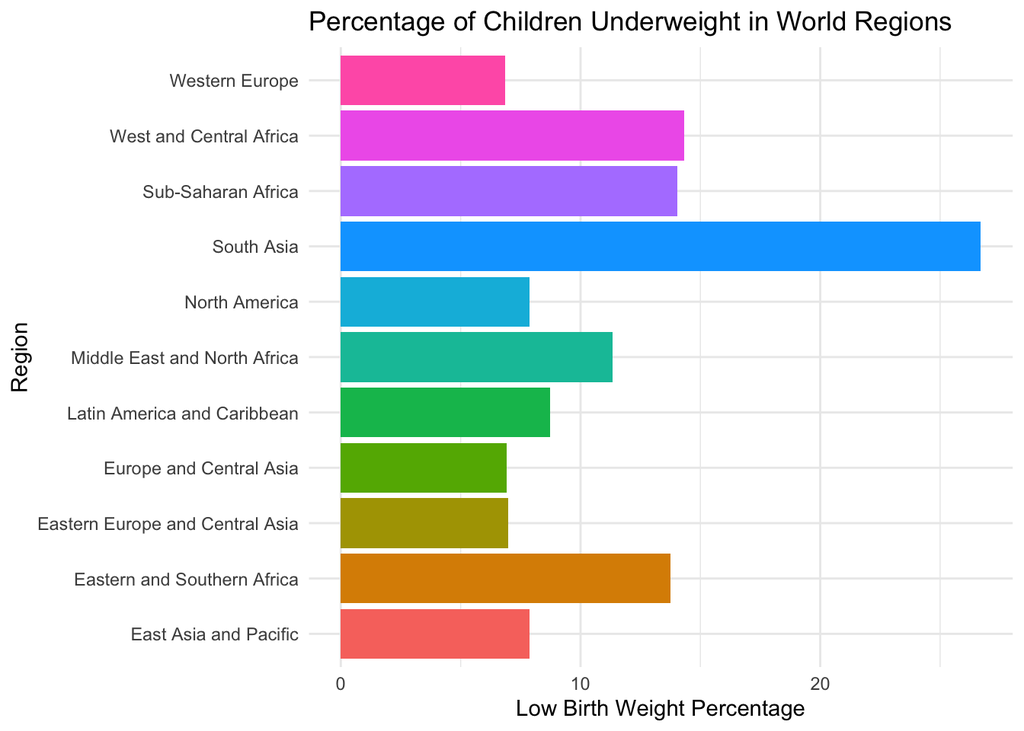

## Figure Two: Mortality Rates and Income per Capita

This figure shows that over time, mortality rates have decreased. (We realize that the colors for income may be difficult to decipher, so we may edit the color to regions.)

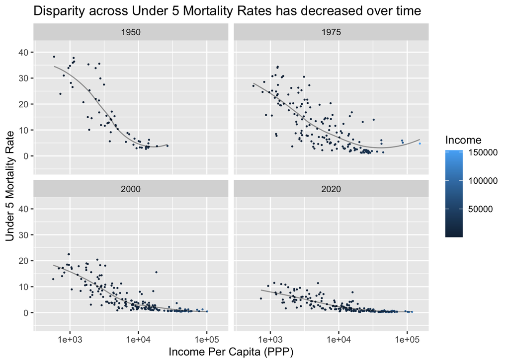

## Figure Three: Relationship between Income and Infant’s that are exclusively breastfed

This is our first attempt at exploring a variable from the nutrition data set with income per capita. Here we are able to see that as income increases, exclusive breast feeding for children’s nutrition decreases. Exclusive breast feeding, according to this data, is described as the

```
> Percentage of infants 0-5 months of age who were fed exclusively with breastmilk during the previous day.
```

This relationship with income could signify that higher income regions are more likely to have alternatives to breastfeeding for infants. Of course this is just a hypothesis, but a question to keep in mind.

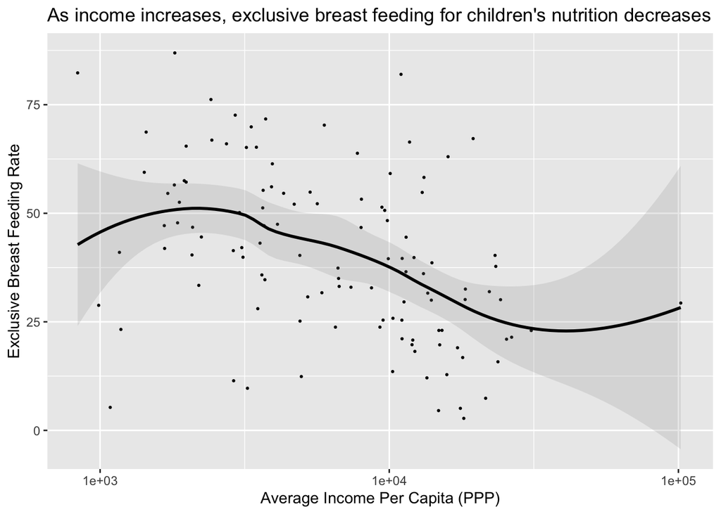

## Figure Four: Relationship between Income per capita and Child Diet Diversity

```
>Percentage of children who received foods from at least 5 out of 8 defined food groups during the previos day.
```

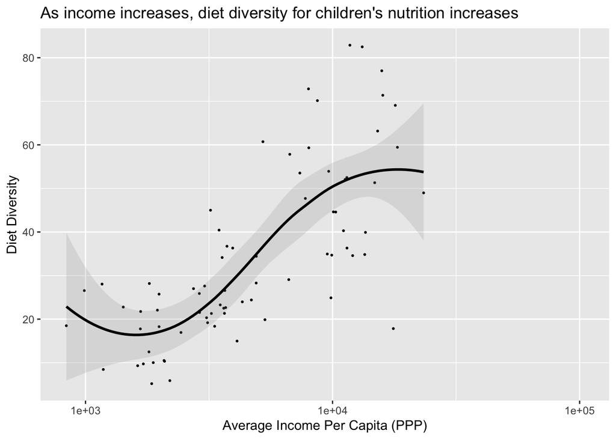

## Figure Five: World Map: Under 5 Mortality Rates across countries

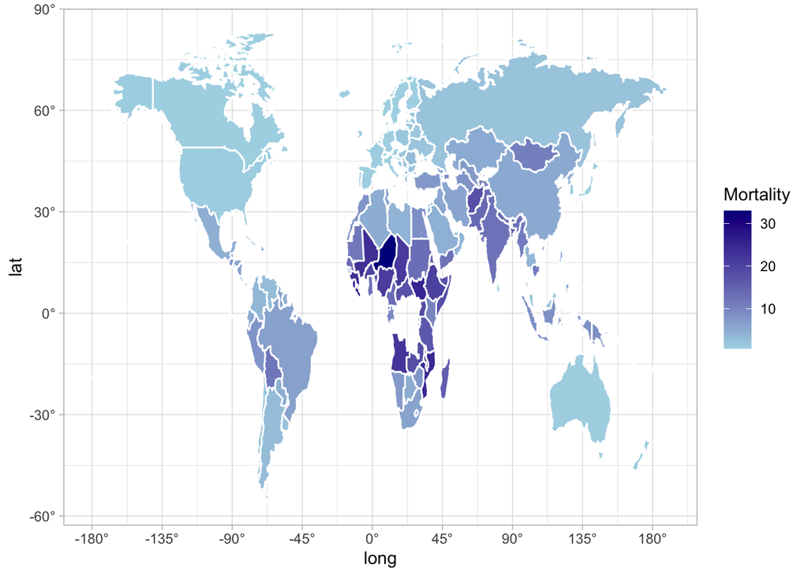

## Figure Six: Visualizing mortality by world region (all rates over 1950-2020)

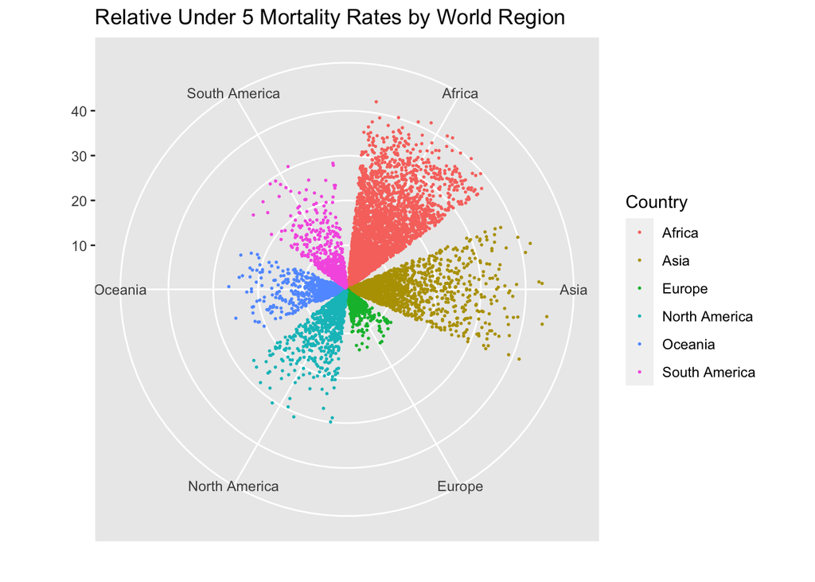

## Figure Seven: correlation between under 5 mortality rates and income per capita

```r
data(income_mortality)
a <- cbind(income_mortality$'Mortality', income_mortality$'Income')
a2<-na.omit(a)
cor = cor(a2[,1],a2[,2])
#the correlation between the mortality and income
print(cor)
```

```
## [1] -0.4813524
```

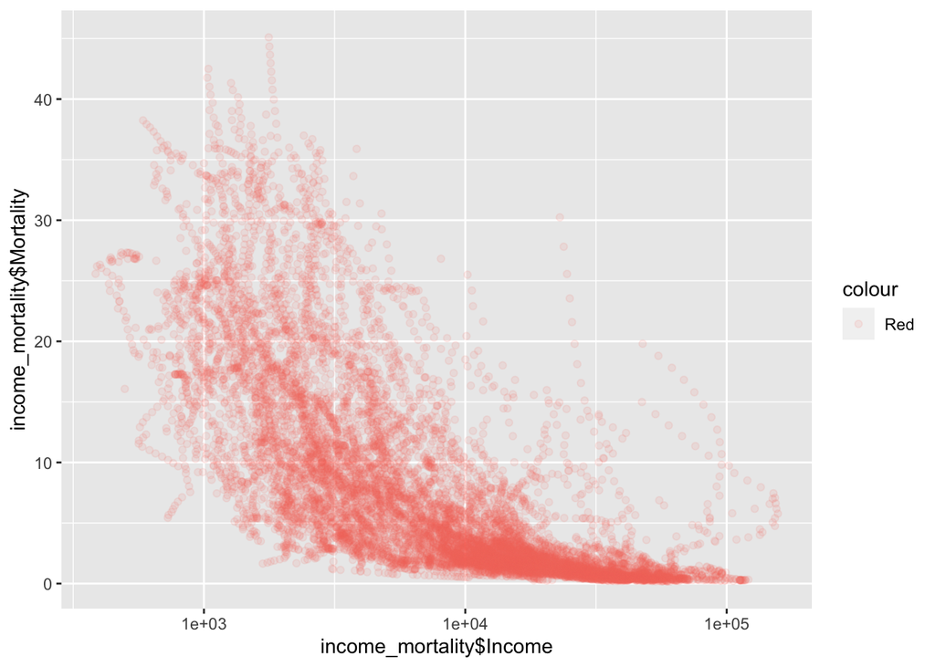

```r
ggplot(data = income_mortality, mapping = aes(x = income_mortality$'Income', y = income_mortality$'Mortality')) +
  scale_x_log10() +
    geom_point(alpha = 0.1, aes(color = 'Red'))
```

## Figures Eight and Nine: Vaccines and Mortality Rates

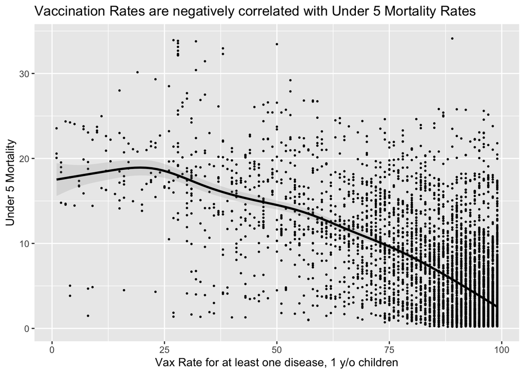

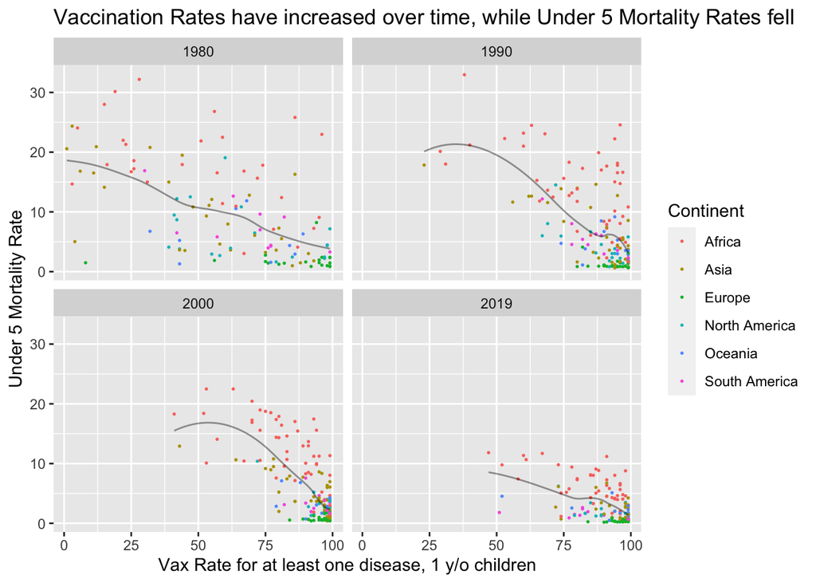

## Modeling and Inference

### Linear Model

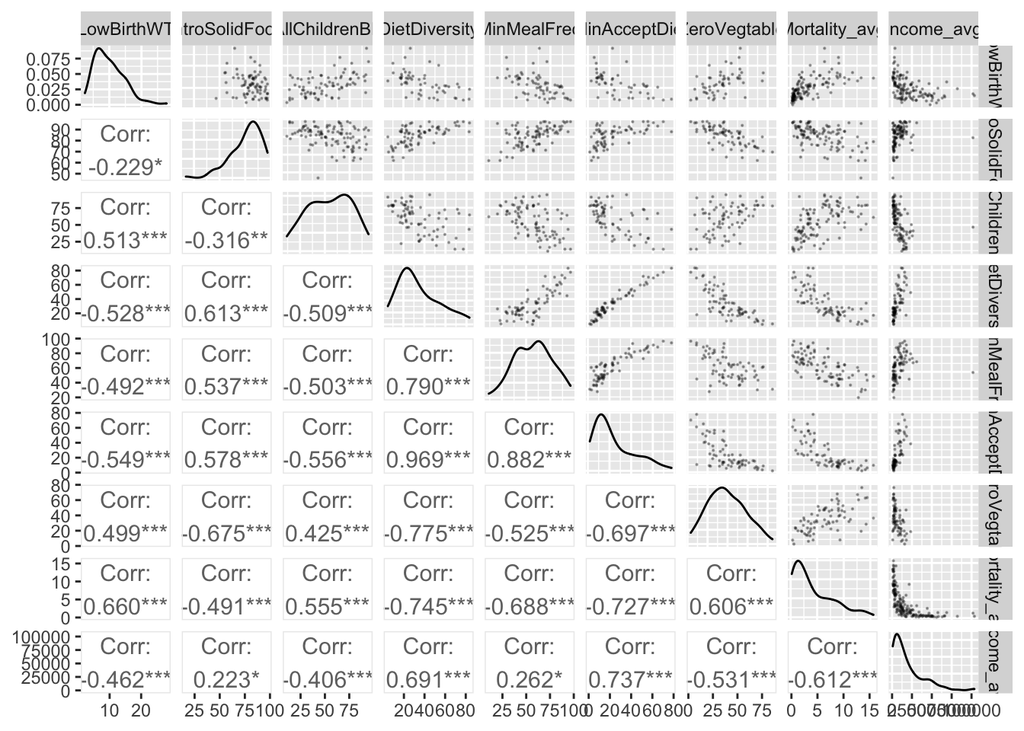

```r
#Scatter Plot and Correlation Matrix of all Variables
model_data <- select(nd_inc_mort_avg, c(2,6,7,10,11,12,13,14,15))
ggpairs(model_data, upper = list(continuous = wrap("points", alpha = 0.3, size=0.1)),
        lower = list(continuous = wrap('cor', size = 4)))
```

```r
model <- lm(nd_inc_mort_avg$Mortality_avg ~ nd_inc_mort_avg$LowBirthWT + nd_inc_mort_avg$Income_avg + nd_inc_mort_avg$ExclusiveBreastFeeding + nd_inc_mort_avg$DietDiversity + nd_inc_mort_avg$ZeroVegtable)
summary(model)
```

```
##
## Call:
## lm(formula = nd_inc_mort_avg$Mortality_avg ~ nd_inc_mort_avg$LowBirthWT +
##     nd_inc_mort_avg$Income_avg + nd_inc_mort_avg$ExclusiveBreastFeeding +
##     nd_inc_mort_avg$DietDiversity + nd_inc_mort_avg$ZeroVegtable)
##
## Residuals:
##     Min      1Q  Median      3Q     Max
## -3.6243 -1.4349 -0.2677  1.2464  6.4726
##
## Coefficients:
##                                          Estimate Std. Error t value Pr(>|t|)
## (Intercept)                             1.069e+01  2.485e+00   4.301 8.52e-05
## nd_inc_mort_avg$LowBirthWT              1.041e-01  7.251e-02   1.436  0.15773
## nd_inc_mort_avg$Income_avg             -2.489e-04  8.257e-05  -3.014  0.00415
## nd_inc_mort_avg$ExclusiveBreastFeeding -4.110e-03  1.917e-02  -0.214  0.83114
## nd_inc_mort_avg$DietDiversity          -8.427e-02  2.545e-02  -3.312  0.00179
## nd_inc_mort_avg$ZeroVegtable           -2.384e-02  2.857e-02  -0.835  0.40811
##
## (Intercept)                            ***
## nd_inc_mort_avg$LowBirthWT
## nd_inc_mort_avg$Income_avg             **
## nd_inc_mort_avg$ExclusiveBreastFeeding
## nd_inc_mort_avg$DietDiversity          **
## nd_inc_mort_avg$ZeroVegtable
## ---
## Signif. codes:  0 '***' 0.001 '**' 0.01 '*' 0.05 '.' 0.1 ' ' 1
##
## Residual standard error: 2.129 on 47 degrees of freedom
##   (115 observations deleted due to missingness)
## Multiple R-squared:  0.6743, Adjusted R-squared:  0.6397
## F-statistic: 19.46 on 5 and 47 DF,  p-value: 1.879e-10
```